# Regression Models Course Project

Michael Atkins

Tuesday, March 10, 2015

EXPLORING THE DATA

I then explored the data utilizing a collorized scatterplot matrix and determined that the biggest determinates of MPG overall other than transmission were HP, CYL, DISP, and WT, which makes sense empirically. See “Appendix 3”

I further explored the relationships between the HP, CYL, DISP, and WT variables utilizing regression regression models, plotting each model with regression lines overlayed for manual transmission (blue) and automatic transmission (green). See “Appendix 4”

FITTING THE REGRESSION MODELS

After initial data exploration, I began to generate and attempt to fit regression models, starting with HP, CYL, DISP, and WT along with AM as the independent variables. See “Appendix 5”

Then I summarized the fit analysis of the variance of the base model, noting that HP, CYL, and WT appeared to be the primary determining variables other than AM. See “Appendix 6”

I note that the three remaining independent variables, HP, CYL, and WT may potentially be dependent upon one another and the model could be further refined, however, the three variable model has an adjusted R-Squared value of 82.7% and a significant P-Value. I then generated the final regression model. Cars with a manual transmission appear to have higher MPG by 1.48 when HP, CYL, and WT variables are held constant. See “Appendix 8”

ANALYZING THE FIT OF THE MODEL

Finally, I performed an ANOVA anlaysis of the base regression model and the final regression model below. Note that the high F-value of 29.2 and low P-value close to 0 indicating this model is a better fit than relying on tranmission type as the sole independent variable affecting MPG. See “Appendix 9”

PERFORMING MODEL DIAGNOSTICS

To close, I performed a diagnostic on the model below. The model developed above assumes normality and constant variance for the model error term. This diagnostic shows those assumptions are valid. Viewing the diagnostic plots, I note: Residuals vs Fitted - Points are scattered and there appear to be no significant nonconstant variance (heteroscedasticity) and no nonlinearity. Normal Q-Q - Significant departures from the line suggest violations of normality. No such departures are noted here suggesting univariate normality. Scale-Location - Points are scattered in a “constant band” pattern suggesting constant variance. Residuals vs Leverage - There appear to be some outliers in this plot which may deserve further exploration. See “Appendix 10”

APPENDIX

Appendix1

```r
require(ggplot2); require(stats); require(graphics); require(gclus)
df <- mtcars
```

Appendix 2

```r
summary(lm(mpg~am,df))
```

```
##
## Call:
## lm(formula = mpg ~ am, data = df)
##
## Residuals:
##     Min      1Q  Median      3Q     Max
## -9.3923 -3.0923 -0.2974  3.2439  9.5077
##
## Coefficients:
##             Estimate Std. Error t value Pr(>|t|)
## (Intercept)   17.147      1.125  15.247 1.13e-15 ***
## am             7.245      1.764   4.106 0.000285 ***
## ---
## Signif. codes:  0 '***' 0.001 '**' 0.01 '*' 0.05 '.' 0.1 ' ' 1
##
## Residual standard error: 4.902 on 30 degrees of freedom
## Multiple R-squared:  0.3598, Adjusted R-squared:  0.3385
## F-statistic: 16.86 on 1 and 30 DF,  p-value: 0.000285
```

```r
t.test(mpg~am, data=df) ##
```

```
##
##  Welch Two Sample t-test
##
## data:  mpg by am
## t = -3.7671, df = 18.332, p-value = 0.001374
## alternative hypothesis: true difference in means is not equal to 0
## 95 percent confidence interval:
##  -11.280194  -3.209684
## sample estimates:
## mean in group 0 mean in group 1
##        17.14737        24.39231
```

Appendix 3

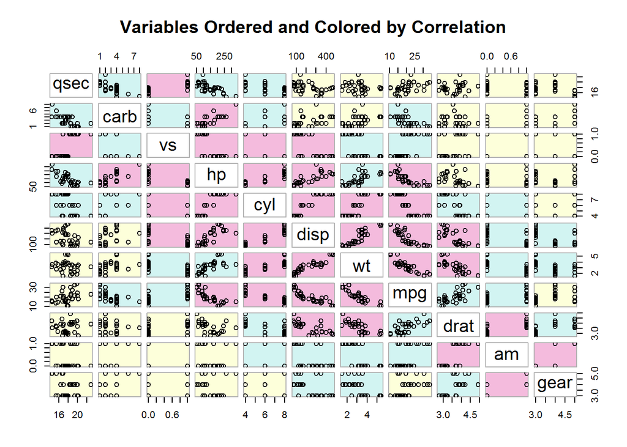

```r
dta <- df[c(1,2,3,4,5,6,7,8,9,10,11)] ## explore data to determine main factors in mpg other than transmission type
dta.r <- abs(cor(dta))
dta.col <- dmat.color(dta.r)
dta.o <- order.single(dta.r)
cpairs(dta, dta.o, panel.colors=dta.col, gap=.5,
       main="Variables Ordered and Colored by Correlation" )
```

Appendix 4

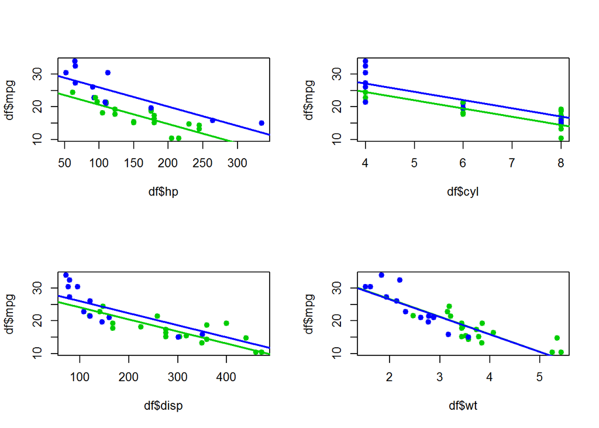

```r
lmbothcyl <- lm(mpg~cyl+am,df) ## regression of mpg by cylinder and transmission
lmbothdisp <- lm(mpg~disp+am,df) ## regression of mpg by displacement and transmission
lmbothhp <- lm(mpg~hp+am,df) ## regression of mpg by horsepower and transmission
lmbothwt <- lm(mpg~wt+am,df) ## regression of mpg by weight and transmission

par(mfrow=c(2,2))
## plot mpg by horsepower with regression by transmission
plot(df$hp,df$mpg,pch=19)
points(df$hp,df$mpg,pch=19,col=((df$am=="1")+3))
abline(c(lmbothhp$coeff[1],lmbothhp$coeff[2]),col="green3",lwd=2)
abline(c(lmbothhp$coeff[1] + lmbothhp$coeff[3],lmbothhp$coeff[2]),col="blue",lwd=2)

## plot mpg by cylinder with regression by transmission
plot(df$cyl,df$mpg,pch=19)
points(df$cyl,df$mpg,pch=19,col=((df$am=="1")+3))
abline(c(lmbothcyl$coeff[1],lmbothcyl$coeff[2]),col="green3",lwd=2)
abline(c(lmbothcyl$coeff[1] + lmbothcyl$coeff[3],lmbothcyl$coeff[2]),col="blue",lwd=2)

## plot mpg by displacement with regression by transmission
plot(df$disp,df$mpg,pch=19)
points(df$disp,df$mpg,pch=19,col=((df$am=="1")+3))
abline(c(lmbothdisp$coeff[1],lmbothdisp$coeff[2]),col="green3",lwd=2)
abline(c(lmbothdisp$coeff[1] + lmbothdisp$coeff[3],lmbothdisp$coeff[2]),col="blue",lwd=2)

## plot mpg by weight with regression by transmission
plot(df$wt,df$mpg,pch=19)
points(df$wt,df$mpg,pch=19,col=((df$am=="1")+3))
abline(c(lmbothwt$coeff[1],lmbothwt$coeff[2]),col="green3",lwd=2)
abline(c(lmbothwt$coeff[1] + lmbothwt$coeff[3],lmbothwt$coeff[2]),col="blue",lwd=2)
```

Appendix 5

```r
summary(lm(mpg ~ hp + cyl + disp + wt + am, df)) ## summarize base model
```

```
##
## Call:
## lm(formula = mpg ~ hp + cyl + disp + wt + am, data = df)
##
## Residuals:
##     Min      1Q  Median      3Q     Max
## -3.5952 -1.5864 -0.7157  1.2821  5.5725
##
## Coefficients:
##             Estimate Std. Error t value Pr(>|t|)
## (Intercept) 38.20280    3.66910  10.412 9.08e-11 ***
## hp          -0.02796    0.01392  -2.008  0.05510 .
## cyl         -1.10638    0.67636  -1.636  0.11393
## disp         0.01226    0.01171   1.047  0.30472
## wt          -3.30262    1.13364  -2.913  0.00726 **
## am           1.55649    1.44054   1.080  0.28984
## ---
## Signif. codes:  0 '***' 0.001 '**' 0.01 '*' 0.05 '.' 0.1 ' ' 1
##
## Residual standard error: 2.505 on 26 degrees of freedom
## Multiple R-squared:  0.8551, Adjusted R-squared:  0.8273
## F-statistic:  30.7 on 5 and 26 DF,  p-value: 4.029e-10
```

Appendix 6

```r
summary(aov(mpg ~ hp + cyl + disp + wt + am, data = df)) ## summarize fit of analysis of base variance model
```

```
##             Df Sum Sq Mean Sq F value   Pr(>F)
## hp           1  678.4   678.4 108.127 9.34e-11 ***
## cyl          1  155.7   155.7  24.817 3.53e-05 ***
## disp         1   30.6    30.6   4.878 0.036216 *
## wt           1   90.9    90.9  14.493 0.000772 ***
## am           1    7.3     7.3   1.167 0.289843
## Residuals   26  163.1     6.3
## ---
## Signif. codes:  0 '***' 0.001 '**' 0.01 '*' 0.05 '.' 0.1 ' ' 1
```

Appendix 7

```r
summary(aov(mpg ~ hp + cyl + wt + am, data = df)) ## summarize fit of analysis of variance model
```

```
##             Df Sum Sq Mean Sq F value   Pr(>F)
## hp           1  678.4   678.4 107.743 6.34e-11 ***
## cyl          1  155.7   155.7  24.729 3.28e-05 ***
## wt           1  115.4   115.4  18.321  0.00021 ***
## am           1    6.6     6.6   1.052  0.31418
## Residuals   27  170.0     6.3
## ---
## Signif. codes:  0 '***' 0.001 '**' 0.01 '*' 0.05 '.' 0.1 ' ' 1
```

Appendix 8

```r
summary(lm(mpg ~ hp + cyl + wt + am, df)) ## summarize regression
```

```
##
## Call:
## lm(formula = mpg ~ hp + cyl + wt + am, data = df)
##
## Residuals:
##     Min      1Q  Median      3Q     Max
## -3.4765 -1.8471 -0.5544  1.2758  5.6608
##
## Coefficients:
##             Estimate Std. Error t value Pr(>|t|)
## (Intercept) 36.14654    3.10478  11.642 4.94e-12 ***
## hp          -0.02495    0.01365  -1.828   0.0786 .
## cyl         -0.74516    0.58279  -1.279   0.2119
## wt          -2.60648    0.91984  -2.834   0.0086 **
## am           1.47805    1.44115   1.026   0.3142
## ---
## Signif. codes:  0 '***' 0.001 '**' 0.01 '*' 0.05 '.' 0.1 ' ' 1
##
## Residual standard error: 2.509 on 27 degrees of freedom
## Multiple R-squared:  0.849,  Adjusted R-squared:  0.8267
## F-statistic: 37.96 on 4 and 27 DF,  p-value: 1.025e-10
```

Appendix 9

```r
anova(lm(mpg ~ am, df), lm(mpg ~ hp + cyl + wt + am, df)) ## (high f value and low p value)
```

```
## Analysis of Variance Table
##
## Model 1: mpg ~ am
## Model 2: mpg ~ hp + cyl + wt + am
##   Res.Df   RSS Df Sum of Sq      F    Pr(>F)
## 1     30 720.9
## 2     27 170.0  3     550.9 29.166 1.274e-08 ***
## ---
## Signif. codes:  0 '***' 0.001 '**' 0.01 '*' 0.05 '.' 0.1 ' ' 1
```

Appendix 10

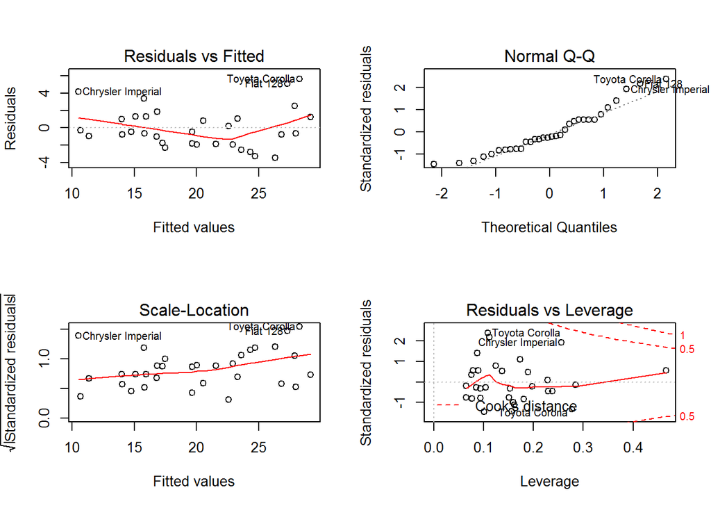

```r
par(mfrow = c(2, 2))
plot(lm(mpg ~ hp + cyl + wt + am, df))
```